# The skin DNA HPV reservoir is transcriptionally silent

Cross-modality decoupling of HPV presence and activity, tested against Shen et al.’s petabase (Logan) papillomavirus survey

Author

Taavi Päll

Published

July 28, 2026

```r
library(tidyverse); library(here)
s  <- read_csv(here("dna_rna_triangulation/skin_dna_vs_rna_summary.csv"), show_col_types = FALSE)
ty <- read_csv(here("dna_rna_triangulation/skin_dna_vs_rna_types.csv"),   show_col_types = FALSE)
gv <- read_csv(here("dna_rna_triangulation/skin_dna_vs_rna_genus.csv"),   show_col_types = FALSE)
topdna  <- ty |> arrange(desc(dna_skin_libs)) |> slice(1:6)
topprod <- ty |> filter(rna_productive > 0) |> arrange(desc(rna_productive)) |> slice(1:6)
fmt_list <- function(x) paste(x, collapse = ", ")
```

## Summary

Our RNA-seq survey argues that cutaneous HPV is **present but transcriptionally quiet** in most skin. That claim is built entirely on transcription, so a sceptic can ask whether the quiet majority is real or just an artefact of what got sequenced. Here we test it against a completely independent **DNA** dataset: Shen et al.’s petabase re-mining of the Logan/SRA assembly for papillomavirus L1 (github.com/syueqiao/pvs_in_logan). The two datasets share **no libraries** (Logan is DNA metagenomes, ours is RNA-seq; the SRR sets are disjoint), so this is a composition comparison, not a per-library join. The result is a clean **decoupling of presence from activity**: the HPV types that dominate the skin DNA reservoir are the ones that are transcriptionally silent, and the transcriptionally productive types are minor or absent from the DNA reservoir. The quiet majority is not a sampling artefact; it is the genuinely dominant β/γ commensal DNA reservoir. Broadening the DNA reservoir to other body sites (Result 3) recovers the textbook tropism from DNA alone: vaginal is overwhelmingly α mucosal, skin is β/γ commensal, gut is a mixture of both, which validates the composition read-out and confirms the skin reservoir is real. A second RNA-activity axis, the anal transition zone (Result 4), closes the loop: its transcriptome is loudly productive α-HPV (100% of productive libraries were α, HPV16-led), while the cutaneous β types that contaminate anal/gut DNA stay silent, so presence and activity separate by genus and by site.

## The two datasets and why they cannot be joined

Shen et al. searched the whole Logan assembly (27 M SRA libraries) for papillomavirus L1 and released per-library RunInfo, a library-to-cluster master table, and a cluster-to-type demarcation. We restrict their set to the **1735 human skin-metagenome libraries** that carry HPV (`ScientificName` = “human skin metagenome” / “skin metagenome”; the SRA structured `Body_Site` field is essentially unpopulated for these, so the metagenome source label is the tissue key). Because Logan is DNA and our survey is RNA-seq, the two SRR universes are **entirely disjoint** (0 shared libraries out of 12,200 ours and 8,722 HPV+ theirs). That rules out a per-library DNA-vs-RNA validation but makes Shen a genuinely independent, non-redundant DNA layer. We therefore compare **type/genus composition**:

- **DNA presence**: for each HPV type, the number of skin-metagenome libraries carrying it (Shen).
- **RNA activity**: per-type library counts in our curated tiers: presence in unselected skin, and *productive infection* (warts `control_productive` **plus** epidermodysplasia verruciformis `EV`, the two contexts of genuine late-transcript expression; EV is included so β-HPV, which is productive only in EV, is scored fairly).

Cluster-to-type mapping uses Shen’s `best_hit_name` (e.g. “human papillomavirus 24”), joined to our `type_genus.csv`; genus keywords (“Gammapapillomavirus N”) resolve the rest, and only libraries whose cluster is flagged novel/no-hit count toward the novel fraction.

A second correction matters more for the type-level claims. PaVE names variants of a type with a trailing letter, so HPV38B is a subtype of HPV38, HPV14D of HPV14 and HPV57B of HPV57. Our typing panel carries the subtype labels while Shen’s `best_hit_name` carries the bare type, so the two sides never joined and the subtype’s libraries fell into `Unresolved`. Both sides are now normalised onto the parent type (`norm_type()`), which changes conclusions rather than cosmetics: HPV14 goes from zero to **58** skin-DNA libraries and HPV57 from zero to **13**, so neither belongs in the list of productive types with no DNA reservoir, where both previously appeared. That list is now nine types, not eleven. HPV38 gains its subtype’s libraries as well (32 to 94), and all three move from `Unresolved` to their correct genus, which is why β rises to 57.9%.

## Result 1: the genus of the reservoir flips from the genus of activity

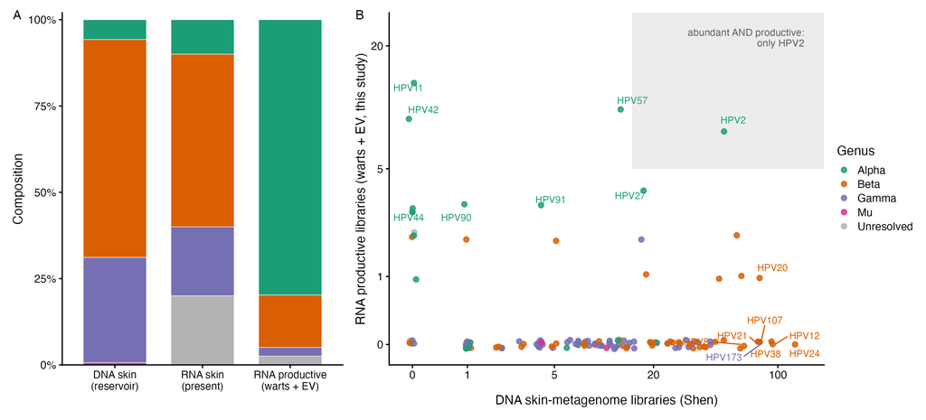

Figure 1: **The skin DNA HPV reservoir is transcriptionally silent.** (A) Genus composition of the human skin-metagenome DNA reservoir (Shen; n = 1735 HPV+ libraries), of the types present in unselected skin (our RNA-seq), and of the types with productive infection (our RNA-seq, warts + EV). The dominant genus flips from β/γ in the DNA reservoir to α in the productive fraction. (B) Per-type DNA skin-metagenome frequency (Shen, x) against RNA productive-library count (this study, y), both on log(x+1) axes, coloured by genus; a handful of extreme types are labelled. The productive types (top-left, mostly α wart types) are DNA-rare or absent, the DNA-abundant types (bottom-right, β/γ) are transcriptionally silent, and the “abundant AND productive” corner is empty but for HPV2.

The skin DNA reservoir is a β/γ commensal community: **57.9%** of HPV+ skin-metagenome libraries carry a Betapapillomavirus and **40.7%** a Gammapapillomavirus, against only **7.4%** carrying an Alphapapillomavirus (Figure 1 A, left). The transcriptionally productive fraction is the mirror image: it is dominated by **Alphapapillomavirus** (Figure 1 A, right). The genus that fills the reservoir is not the genus that is active.

A striking side-note: **14.5%** of skin-metagenome libraries carry a PV cluster that matches nothing in the reference databases, i.e. a candidate novel type. The cutaneous β/γ reservoir remains substantially under-catalogued even at petabase scale.

## Result 2: presence and activity are decoupled at the type level

Ranking types within each axis makes the decoupling explicit (Figure 1 B). The most DNA-abundant skin types are β/γ commensals that are transcriptionally silent: the top of the DNA ranking is HPV24 (128 libraries), HPV12 (96 libraries), HPV38 (94 libraries), HPV20 (81 libraries), HPV107 (80 libraries), HPV173 (80 libraries), and every one of them has essentially no productive-library signal. Conversely, the productive types are α wart viruses that are DNA-rare or entirely absent from the skin reservoir: HPV11 (14 productive), HPV57 (10 productive), HPV42 (9 productive), HPV2 (8 productive), HPV27 (4 productive), HPV91 (3 productive). The archetypal wart types **HPV-MKN1NR, HPV11, HPV42, HPV44, HPV47, HPV52, HPV6, HPV7, HPV78** have **zero** detections across all 1735 skin-metagenome libraries.

Of the top 20 types on each axis, only **5** are shared (HPV14, HPV17, HPV2, HPV20, HPV5), and they are the informative exceptions rather than a counter-example:

- **HPV2** is the single α type that is both a frequent skin DNA resident and productive (the “abundant AND productive” corner in Figure 1 B), the common-wart virus that also persists as skin flora.
- **HPV5, HPV17, HPV20** are the β EV-types: they are abundant in the DNA reservoir *and* weakly productive, but their productivity comes from the EV context, i.e. it is drawn *from* the commensal reservoir rather than decoupled from it.

So the decoupling is genus- and context-specific: **α wart productivity is independent of the skin DNA reservoir, whereas the little β productivity that exists (in EV) is sampled from it.**

```r
bind_rows(
  ty |> arrange(desc(dna_skin_libs)) |> slice(1:12) |> mutate(panel = "Most DNA-abundant"),
  ty |> filter(rna_productive > 0) |> arrange(desc(rna_productive)) |> mutate(panel = "Productive (warts + EV)")
) |> distinct(type, .keep_all = TRUE) |>
  transmute(Group = panel, Type = type, Genus = genus, `DNA skin libs` = dna_skin_libs,
            `RNA skin` = rna_skin_present, `RNA productive` = rna_productive) |>
  knitr::kable()
```

Top skin-DNA types and all productive types, DNA presence vs RNA activity.

| Group | Type | Genus | DNA skin libs | RNA skin | RNA productive |
| --- | --- | --- | --- | --- | --- |
| Most DNA-abundant | HPV24 | Beta | 128 | 0 | 0 |
| Most DNA-abundant | HPV12 | Beta | 96 | 0 | 0 |
| Most DNA-abundant | HPV38 | Beta | 94 | 0 | 0 |
| Most DNA-abundant | HPV20 | Beta | 81 | 0 | 1 |
| Most DNA-abundant | HPV107 | Beta | 80 | 0 | 0 |
| Most DNA-abundant | HPV173 | Gamma | 80 | 0 | 0 |
| Most DNA-abundant | HPV21 | Beta | 78 | 0 | 0 |
| Most DNA-abundant | HPV8 | Beta | 63 | 0 | 0 |
| Most DNA-abundant | HPV5 | Beta | 62 | 0 | 1 |
| Most DNA-abundant | HPV75 | Beta | 61 | 0 | 0 |
| Most DNA-abundant | HPV14 | Beta | 58 | 0 | 2 |
| Most DNA-abundant | HPV15 | Beta | 49 | 0 | 0 |
| Productive (warts + EV) | HPV11 | Alpha | 0 | 0 | 14 |
| Productive (warts + EV) | HPV57 | Alpha | 13 | 0 | 10 |
| Productive (warts + EV) | HPV42 | Alpha | 0 | 0 | 9 |
| Productive (warts + EV) | HPV2 | Alpha | 49 | 0 | 8 |
| Productive (warts + EV) | HPV27 | Alpha | 17 | 0 | 4 |
| Productive (warts + EV) | HPV91 | Alpha | 4 | 0 | 3 |
| Productive (warts + EV) | HPV90 | Alpha | 1 | 0 | 3 |
| Productive (warts + EV) | HPV44 | Alpha | 0 | 0 | 3 |
| Productive (warts + EV) | HPV52 | Alpha | 0 | 0 | 3 |
| Productive (warts + EV) | HPV6 | Alpha | 0 | 0 | 3 |
| Productive (warts + EV) | HPV4 | Gamma | 17 | 0 | 2 |
| Productive (warts + EV) | HPV9 | Beta | 5 | 0 | 2 |
| Productive (warts + EV) | HPV25 | Beta | 1 | 0 | 2 |
| Productive (warts + EV) | HPV-MKN1NR | Unresolved | 0 | 0 | 2 |
| Productive (warts + EV) | HPV47 | Beta | 0 | 0 | 2 |
| Productive (warts + EV) | HPV78 | Alpha | 0 | 0 | 2 |
| Productive (warts + EV) | HPV17 | Beta | 49 | 0 | 1 |
| Productive (warts + EV) | HPV37 | Beta | 19 | 0 | 1 |
| Productive (warts + EV) | HPV7 | Alpha | 0 | 0 | 1 |

## Result 3: the reservoir across body sites recovers known tropism

Our RNA-seq survey is skin-only (tissue categories: 9,037 skin, no vaginal or gut), so vaginal and gut cannot be given a matched RNA-activity axis. What they *can* show is the **DNA reservoir** itself, and comparing it across body sites is a strong internal check: if the petabase reservoir is real signal rather than noise, its genus composition should recover the textbook tropism of the papillomaviruses. It does.

```r
rg <- read_csv(here("dna_rna_triangulation/reservoir_by_tissue_genus.csv"), show_col_types = FALSE)
gp <- function(tis, g) round(100 * rg$prop[rg$tissue == tis & rg$genus == g], 1)
nv <- function(tis) round(100 * rg$prop[rg$tissue == tis & rg$genus == "Novel_any"], 1)
nlib <- function(tis) format(rg$n_lib[rg$tissue == tis][1], big.mark = ",")
```

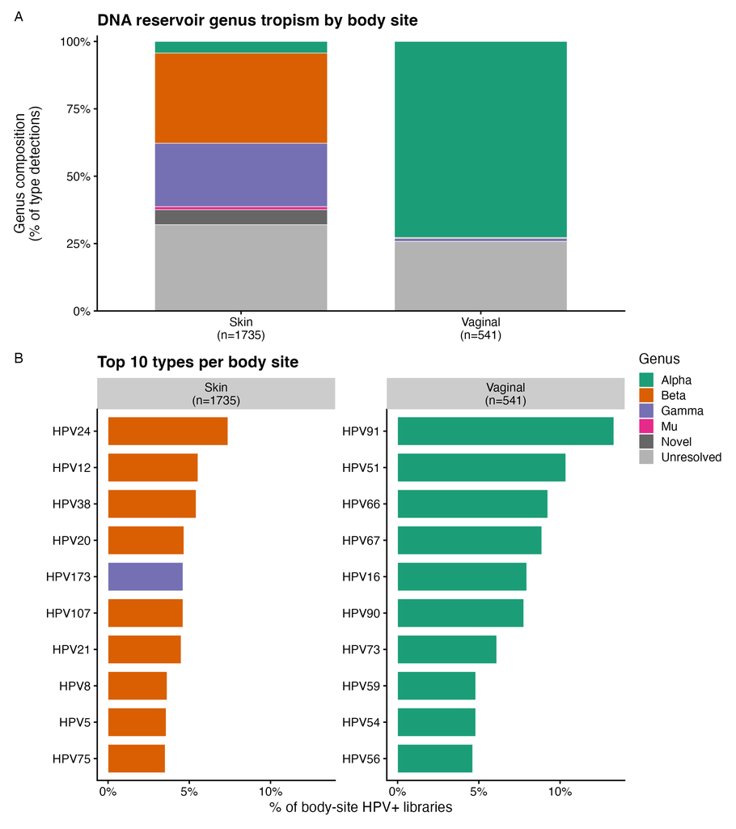

Figure 2: **The HPV DNA reservoir across body sites recovers known genus tropism.** (A) Genus composition of the HPV+ DNA reservoir (Shen; skin n=1,735, vaginal n=541 libraries), normalised within body site (a co-infected library contributes to more than one genus, so this is the composition of type detections). Skin is a β/γ commensal reservoir and the vaginal reservoir is overwhelmingly α mucosal. (B) The ten most frequent types per body site, coloured by genus. The gut, a collection-route control rather than a third reservoir, is in Figure 3.

The two sites with a niche of their own give two distinct, biologically expected reservoirs (Figure 2):

- **Skin** is a Betapapillomavirus/Gammapapillomavirus commensal reservoir (β 57.9%, γ 40.7% of detections, α only 7.4%), the same composition analysed above.
- **Vaginal** is overwhelmingly **Alphapapillomavirus** (α 84.5%, β 0.4%, γ 1.3%); its top types are the classic mucosal set (HPV91, 51, 66, 67, 16, 90), mixing high- and low-risk α. This is the textbook mucosal niche, recovered here purely from DNA metagenome assembly.

The novel-cluster fraction tracks how well each niche is catalogued: **14.5%** of skin libraries carry an unclassified PV cluster, versus only **0.2%** of vaginal libraries: the mucosal α types are exhaustively described, while the cutaneous β/γ reservoir is not.

The same tabulation for the **gut** is kept separate, and out of the main comparison, because it does not describe a gut niche (Figure 3). Gut libraries are a **mixture**: α 30.5%, β 34.9%, γ 15.4%, and their top types interleave mucosal α (HPV16, HPV6, HPV56) with cutaneous β skin types (HPV24, HPV124), exactly the signature of stool/gut metagenomes picking up both mucosal shedding and **perianal-skin commensal β-HPV**: collection-route carry-over, independently seen in rectal-swab gut metagenomes (the eluring aging cohort). Read that way it is a useful control, since it shows the assembly recovers the genus of whatever skin the sampling route touches, but it is not evidence of a third reservoir, so it belongs in the supplement. Its novel fraction (**9.6%**) sits with skin’s, as expected if its β/γ content is skin in origin.

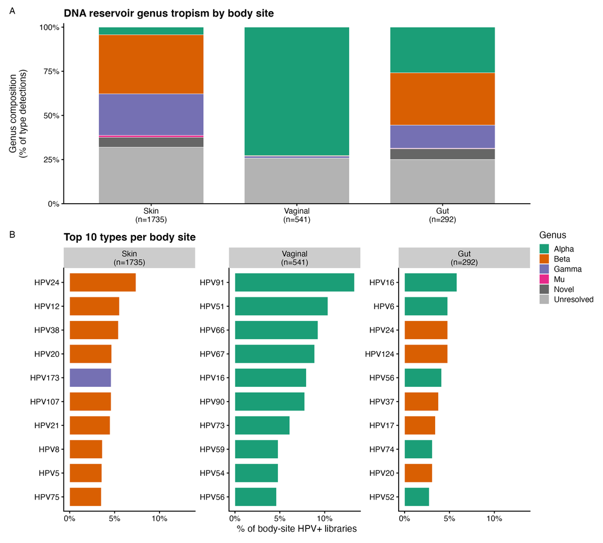

Figure 3: **The gut DNA reservoir is a collection-route mixture, not a niche.** The three-site version of Figure 2, with the gut (n=292 libraries) included. Panels and colours as in Figure 2.

That the reservoir cleanly reconstructs the vaginal-α / skin-β/γ tropism from DNA alone validates the composition read-out used in Results 1–2: the skin reservoir’s β/γ dominance and the type-level presence/activity decoupling are not analysis artefacts.

## Result 4: the anal niche, an independent RNA-activity axis

The skin decoupling (Results 1–2) rests on a skin RNA-activity axis; the gut/vaginal comparisons (Result 3) could only show the DNA reservoir, because our RNA survey was skin-only. To close that gap for one of the two sites, we ran the HPV-typing pipeline over the anal/anorectal RNA-seq that the survey had never touched: a small, clean niche (anal squamous-cell-carcinoma lines are rare, so the cell-line burden that dominates cervical RNA is minimal here). This gives a genuine RNA-activity axis for the anal transition zone, to set against the mixed gut DNA reservoir of Result 3.

```r
ap  <- read_csv(here("dna_rna_triangulation/anorectal_pilot/anal_pilot_summary.csv"), show_col_types = FALSE)
apt <- read_csv(here("dna_rna_triangulation/anorectal_pilot/anal_productive_types.csv"), show_col_types = FALSE)
a <- function(k) ap$value[ap$metric == k]
top_prod <- apt |> slice_max(productive_samples, n = 4)
```

Anal tissue is genuinely HPV-rich, unlike healthy skin. Of 681 libraries typed, 230 were HPV-positive (**34%**; 37% across the anal-carcinoma studies), an order of magnitude above the 2–4% of primary skin. The 5 cell lines flagged by the curation were **all HPV-negative** (0 positive), so the signal is clinical tissue, not contamination.

And the activity is overwhelmingly productive α. Of 161 libraries with late (L1/L2 capsid) transcripts (the productive-infection signal), **100% were Alphapapillomavirus**, led by HPV16 (91), HPV11 (22), HPV6 (14), HPV18 (7). Every one of the 22 productively-expressed types was α; no β or γ type reached productive expression in a single anal library.

This completes the cross-modality decoupling for a second niche, and it does double duty. First it **reinforces** the decoupling: the anal transition zone sits directly against perianal skin, so the cutaneous β types that leak into gut/anal DNA metagenomes (Result 3: the gut reservoir was a mixture of mucosal α and cutaneous β such as HPV24 and HPV124) are entirely **silent** in the anal transcriptome: present in DNA, absent from activity. Second, it supplies a **positive control** the skin analysis lacked: where the skin story is “present but quiet”, the anal α-HPV is loudly productive (HPV16 alone drove 91 productive libraries), exactly as expected for the HPV16-driven anal carcinoma niche and mirroring the cervix. Presence and activity are decoupled by **genus and site**: mucosal α is productive where it resides (cervix, anus), cutaneous β/γ is a quiet DNA reservoir wherever it is found (skin, and as contamination in gut/anal DNA).

## Conclusion

An orthogonal, DNA-based, whole-SRA survey confirms and sharpens the present-but-quiet thesis: the transcriptionally silent majority of cutaneous HPV is the genuinely **dominant β/γ commensal DNA reservoir**, not an artefact of RNA sampling, and transcriptional productivity is confined to a distinct, DNA-minor set of α wart types (with EV-β productivity the lone strand drawn from the reservoir). A second niche, the anal transition zone, closes the loop from the other direction: its RNA is loudly productive α-HPV (HPV16-driven), while the cutaneous β types that contaminate anal DNA metagenomes stay silent, so presence and activity separate by genus and by site, not by chance. The reproducible scripts, tables and figures are in this directory (`shen_skin_dna_vs_rna.R`, `shen_reservoir_by_tissue.R`, `anorectal_pilot/`).

## What the cervical/vaginal run would add

The anal pilot is the smaller, cleaner half of the mucosal story; the cervical/vaginal set is the larger and more decisive one, and it is the natural next run (`../rna_extension_scoping/`, ~6,400 new curation-ready libraries). Three things it would resolve that the current work only implies:

1. **The direct vaginal presence-vs-activity test.** Result 3 showed the vaginal DNA reservoir is 84% α, dominated by HPV91/51/66/67/16/90. A vaginal RNA-activity axis would ask, for the same tissue, whether those DNA-frequent types are the *productive* ones, the exact within-tissue join we could only do for skin. The mucosal prediction is that they largely coincide (unlike skin, where DNA-frequent β is silent), which would make the cervix the clean contrast case to skin: a niche where presence *does* predict activity.
2. **A high-risk vs low-risk activity gradient.** With thousands of libraries spanning normal cervix → CIN → carcinoma, the productive signal can be resolved by lesion grade, testing whether high-risk α (HPV16/18/31/33/45) dominate productive expression in disease while low-risk α (HPV6/11) and the many commensal mucosal types stay quiet, the mucosal analogue of the skin β-reservoir story.
3. **A real stress-test of the cell-line curation.** Cervical RNA-seq is ~62% cell-line-tripped (HeLa/SiHa/CaSki), versus near-zero for anal. The anal pilot showed the curation cleanly zeroed out its few cell lines; the cervical run is where that machinery earns its keep at scale, and a clean α-productive tissue signal emerging from behind the HeLa wall would be the strongest possible demonstration that the contamination-aware framework works.

The one operational lesson from this pilot: run the cervical set with the per-sample cell-line classifier and the SNP/contamination checks at full strength, and expect the tissue-curation step (not the typing) to be the real work, given how much of the cervical archive is immortalised-line material.